# Mid-term project

Author

Sultan Nawaz & MUHAMMAD USMAN KHALID

# 1 Mid-term project GitHub repository URL:

https://github.com/SultanNawaz/2024dsa_midproject_group7.git

# 2 Introduction

With the increasing population, the world needs more food to feed on and for such purposes, intensive agriculture is taking place around the globe to feed and gain profits. To get more agricultural outputs many practices have been implemented and adopted by the agricultural and farming community. Using inputs like phosphatic fertilizers and chemicals including weedicides and pesticides to prevent weeds and pests are harmful to both soil and plants.

Phosphorus is an important nutrient to both plants and soil. Phosphorus has its pros and cons, therefore, its wide use is monitored to reduce environmental effects. The use of phosphorus in excess amounts is more often associated with Eutrophication, which is the leading threat to marine life.

With the increased use of phosphatic fertilizers, worldwide phosphorus reserves are declining at a very high speed. Researchers all over the globe are active in research to come up with a protocol where we could identify and use microbes to make P available which is usually bound to soil aggregates due to its complexes with Al and Fe in low pH soils and bound to Ca and Mg in alkaline soils. Much research published has witnessed the P-mineralization with the help of microbes including some bacteria and fungi. Keeping the same in mind we came up with a research where we will use some microbes and will use it with certain rates to assess what rates can be significant to use.

**Research gap:**

Previous research conducted on LEM does not give a suggestion/recommendation for the application rates to crops. Additionally, phosphorus behaves differently in different soil and environmental conditions. Applying LEM at different rates will enable us to understand the potential of microbes in nutrient uptake by plants which will add significance in reducing P levels of the soil. The data on P content in the soil after LEM application will be collected for the next 2 years, and will help us to assess whether or not LEM has helped us to lower the P concentration in the soil.

# 3 Hypothesis and objectives

# 4 **Objectives:** The objective of our study is to determine phosphorus content with the application of locally effective microbes.

Hypothesis: Locally effective microbes will lower the phosphorus levels.

# 5 Material and Methods

Site and liquid effective microbes preparation: This study was conducted at Horticulture farm in Watkinisville, Georgia in 2023 to test the effectiveness of locally effective microbes (LEM) in phosphorus draw-down at organic fields that was fertilized with organic inputs for 10 years. To make solid LEM, inuculum was collected from a hardwood, pine and mixed forest located in Watkinisville and was kept at in air tight container at room temperature for at least 4 weeks for fermentation after mixing it with crushed charcoal, yeast, 50 pounds of semolina, a gallon of molasses,unpasteurized goat milk and water. After fermentation, the liquid LEM was prepared by taking 3kg of solid LEM and hanging it in a 12 gallon bucket with a gallon of molasses and 8 gallons of water and keeping at room temperature for at least 3 weeks. This liquid LEM will be applied to the field.

Planting, LEM application and soil sampling:

## 5.1 Study design

Randomized complete block design with repeated measure will be used in this project. Factor include locally effective microbes rates with three levels (0, 1.8L/m2 and 3.6L/m2) applied to 4 blocks making 36 experimental plots in total. Every block received each level of LEM 3 times as replicated thrice.

## 5.2 Statistical analysis

Linear assumptions including independence, normality, homeocedasity and outliers were checked and they did met.

## 5.3 Running Code

##Here we will load the packages that we think will be used in this data set

```r
#install.packages("tidyverse")
#install.packages("car")
#install.packages("lme4")
#install.packages("broom")
#install.packages("emmeans")
#install.packages("multcomp")

#Loading packaes to library

library(tidyverse) # for data wrangling and plotting
library(car) # for Anova function
library(lme4)
library(broom) # for model residuals extraction
library(emmeans) # for model mean extraction
library(multcomp) # for pairwise comparison letter display
```

{##Here we are importing our data from the source file}

```r
      mid_df <- read.csv("../Data/Mid-Term Project.csv")

mid_df
```

```
   Replication Treatment LEM.rate..L.m2. PO4.mg.kg
1            1         1             1.8  31.53751
2            1         2             3.6  67.36331
3            1         3             0.0 147.80907
4            1         4             1.8 101.51213
5            1         5             1.8  64.50119
6            1         6             3.6  95.36535
7            1         7             0.0 117.02851
8            1         8             3.6  84.05944
9            1         9             0.0  92.67886
10           2         1             0.0  50.19393
11           2         2             3.6  54.21269
12           2         3             1.8 134.82607
13           2         4             0.0 113.55204
14           2         5             3.6 109.30913
```

[output cut: 22 more lines]

##data imported looks okay to run for exploratory data analysis

# 6 b) EDA tables

{##We are running code for explanatory data analysis to understand data,idetify relationship, check data quality etc.}

```r
summary(mid_df)
```

```
  Replication     Treatment LEM.rate..L.m2.   PO4.mg.kg
 Min.   :1.00   Min.   :1   Min.   :0.0     Min.   : 12.02
 1st Qu.:1.75   1st Qu.:3   1st Qu.:0.0     1st Qu.: 41.30
 Median :2.50   Median :5   Median :1.8     Median : 65.34
 Mean   :2.50   Mean   :5   Mean   :1.8     Mean   : 67.73
 3rd Qu.:3.25   3rd Qu.:7   3rd Qu.:3.6     3rd Qu.: 86.21
 Max.   :4.00   Max.   :9   Max.   :3.6     Max.   :147.81
```

##The summary above shows that there are 9 treatments with LEM rates of 0, 1.8, and 3.6 where PO4 ranged from a minimum of 12.02 to a maximum of 147.81

{##WE will use glimpse here to see how our data looks like}

```r
glimpse(mid_df)
```

```
Rows: 36
Columns: 4
$ Replication     <int> 1, 1, 1, 1, 1, 1, 1, 1, 1, 2, 2, 2, 2, 2, 2, 2, 2, 2, …
$ Treatment       <int> 1, 2, 3, 4, 5, 6, 7, 8, 9, 1, 2, 3, 4, 5, 6, 7, 8, 9, …
$ LEM.rate..L.m2. <dbl> 1.8, 3.6, 0.0, 1.8, 1.8, 3.6, 0.0, 3.6, 0.0, 0.0, 3.6,…
$ PO4.mg.kg       <dbl> 31.53751, 67.36331, 147.80907, 101.51213, 64.50119, 95…
```

# 7 c) Wrangling

{## Here come the process of gathering and transforming the data according to our required analysis.}

```r
mid_dfw <- mid_df %>%
  mutate(Replication = factor(Replication),
         LEM.rate..L.m2. = factor(LEM.rate..L.m2.)

         ) %>%
  janitor::clean_names()

mid_dfw
```

```
   replication treatment lem_rate_l_m2 po4_mg_kg
1            1         1           1.8  31.53751
2            1         2           3.6  67.36331
3            1         3             0 147.80907
4            1         4           1.8 101.51213
5            1         5           1.8  64.50119
6            1         6           3.6  95.36535
7            1         7             0 117.02851
8            1         8           3.6  84.05944
9            1         9             0  92.67886
10           2         1             0  50.19393
11           2         2           3.6  54.21269
12           2         3           1.8 134.82607
13           2         4             0 113.55204
14           2         5           3.6 109.30913
```

[output cut: 22 more lines]

## 7.1 Additionally we did use the Janitor function to clean the names and make it more presntable.

```r
summary(mid_dfw)
```

```
 replication   treatment lem_rate_l_m2   po4_mg_kg
 1:9         Min.   :1   0  :12        Min.   : 12.02
 2:9         1st Qu.:3   1.8:12        1st Qu.: 41.30
 3:9         Median :5   3.6:12        Median : 65.34
 4:9         Mean   :5                 Mean   : 67.73
             3rd Qu.:7                 3rd Qu.: 86.21
             Max.   :9                 Max.   :147.81
```

```r
mid_dfw
```

```
   replication treatment lem_rate_l_m2 po4_mg_kg
1            1         1           1.8  31.53751
2            1         2           3.6  67.36331
3            1         3             0 147.80907
4            1         4           1.8 101.51213
5            1         5           1.8  64.50119
6            1         6           3.6  95.36535
7            1         7             0 117.02851
8            1         8           3.6  84.05944
9            1         9             0  92.67886
10           2         1             0  50.19393
11           2         2           3.6  54.21269
12           2         3           1.8 134.82607
13           2         4             0 113.55204
14           2         5           3.6 109.30913
```

[output cut: 22 more lines]

# 8 d) EDA plots

{## In this chunk we presnted our data in plot (boxplot) where data points of data sets are presented with three different colors, each representing level/rate of LEM.}

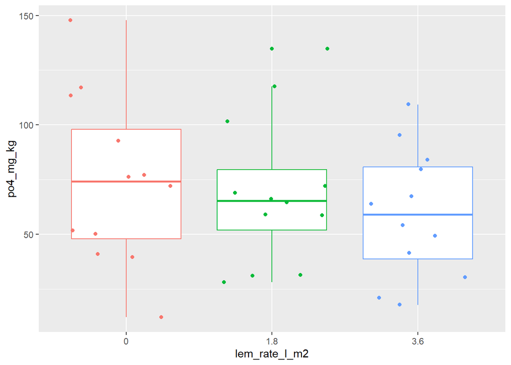

```r
ggplot(mid_dfw, aes(x = lem_rate_l_m2,
                    y = po4_mg_kg,
                    color = lem_rate_l_m2)) +
  geom_boxplot() +
  geom_jitter() +
  theme(legend.position = "none")
```

##Box plots here suggest that LEM rate of Zero has higher values but we can confirm it after running the models and see ANOVA

# 9 e) Statistical model

## 9.1 ##Mixed-effect modeling in R

We will use a mixed effect model here to address heterogeneous variance, separate variance due to random sampling, accounting for random effects.

To account for more than one variance component (i.e., random effects and error), we can use function `lmer()` from package `lme4`.

```r
# Changing to sum-to-zero contrast
options(contrasts = c("contr.sum", "contr.poly"))

# Model fitting
mid_mix_mod <- lmer(po4_mg_kg ~ lem_rate_l_m2 +
                       (1|replication),
                     data = mid_dfw
                       )

mid_dfw
```

```
   replication treatment lem_rate_l_m2 po4_mg_kg
1            1         1           1.8  31.53751
2            1         2           3.6  67.36331
3            1         3             0 147.80907
4            1         4           1.8 101.51213
5            1         5           1.8  64.50119
6            1         6           3.6  95.36535
7            1         7             0 117.02851
8            1         8           3.6  84.05944
9            1         9             0  92.67886
10           2         1             0  50.19393
11           2         2           3.6  54.21269
12           2         3           1.8 134.82607
13           2         4             0 113.55204
14           2         5           3.6 109.30913
```

[output cut: 22 more lines]

```r
# Summary
summary(mid_mix_mod)
```

```
Linear mixed model fit by REML ['lmerMod']
Formula: po4_mg_kg ~ lem_rate_l_m2 + (1 | replication)
   Data: mid_dfw

REML criterion at convergence: 327

Scaled residuals:
     Min       1Q   Median       3Q      Max
-2.08928 -0.70285  0.03733  0.65752  2.03739

Random effects:
 Groups      Name        Variance Std.Dev.
 replication (Intercept) 526.1    22.94
 Residual                731.2    27.04
Number of obs: 36, groups:  replication, 4

Fixed effects:
               Estimate Std. Error t value
(Intercept)      67.730     12.322   5.497
lem_rate_l_m21    6.480      6.373   1.017
lem_rate_l_m22    1.795      6.373   0.282

Correlation of Fixed Effects:
            (Intr) l___21
lm_rt_l_m21  0.000
lm_rt_l_m22  0.000 -0.500
```